# Unit7

HH

10/28/2014

# Unit 7: Introduction.

- Multiple predictors.
- Inference for MLR.
- Model Selection.
- Model Diagnostics.

# Unit 7, Part 1: Multiple Predictors.

```r
library(DAAG);
data(allbacks);
book_mlr=lm(weight ~ volume + cover, data = allbacks);
summary(book_mlr);
```

```
##
## Call:
## lm(formula = weight ~ volume + cover, data = allbacks)
##
## Residuals:
##    Min     1Q Median     3Q    Max
## -110.1  -32.3  -16.1   28.9  210.9
##
## Coefficients:
##              Estimate Std. Error t value Pr(>|t|)
## (Intercept)  197.9628    59.1927    3.34  0.00584 **
## volume         0.7180     0.0615   11.67  6.6e-08 ***
## coverpb     -184.0473    40.4942   -4.55  0.00067 ***
## ---
## Signif. codes:  0 '***' 0.001 '**' 0.01 '*' 0.05 '.' 0.1 ' ' 1
##
## Residual standard error: 78.2 on 12 degrees of freedom
## Multiple R-squared:  0.927,  Adjusted R-squared:  0.915
## F-statistic: 76.7 on 2 and 12 DF,  p-value: 1.45e-07
```

```r
y = 197 + .72*450 - 184.05*0;
y
```

```
## [1] 521
```

## Interaction variables

Are used if the slopes are not the same. (Beyond the scope of the book)

# Unit 7, Part 1: Adjusted R Squared

```r
states = read.csv("http://d396qusza40orc.cloudfront.net/statistics/lec_resources/states.csv");

pov_slr = lm(poverty ~ female_house, data = states);

summary(pov_slr);
```

```
##
## Call:
## lm(formula = poverty ~ female_house, data = states)
##
## Residuals:
##    Min     1Q Median     3Q    Max
## -5.754 -1.825 -0.037  1.556  6.328
##
## Coefficients:
##              Estimate Std. Error t value Pr(>|t|)
## (Intercept)     3.309      1.897    1.74    0.087 .
## female_house    0.691      0.160    4.32  7.5e-05 ***
## ---
## Signif. codes:  0 '***' 0.001 '**' 0.01 '*' 0.05 '.' 0.1 ' ' 1
##
## Residual standard error: 2.66 on 49 degrees of freedom
## Multiple R-squared:  0.276,  Adjusted R-squared:  0.261
## F-statistic: 18.7 on 1 and 49 DF,  p-value: 7.53e-05
```

```r
pov_mlr = lm(poverty ~ female_house + white, data = states);

summary(pov_mlr);
```

```
##
## Call:
## lm(formula = poverty ~ female_house + white, data = states)
##
## Residuals:
##    Min     1Q Median     3Q    Max
## -5.525 -1.853 -0.038  1.377  6.269
##
## Coefficients:
##              Estimate Std. Error t value Pr(>|t|)
## (Intercept)   -2.5789     5.7849   -0.45  0.65774
## female_house   0.8869     0.2419    3.67  0.00061 ***
## white          0.0442     0.0410    1.08  0.28676
## ---
## Signif. codes:  0 '***' 0.001 '**' 0.01 '*' 0.05 '.' 0.1 ' ' 1
##
## Residual standard error: 2.66 on 48 degrees of freedom
## Multiple R-squared:  0.293,  Adjusted R-squared:  0.264
## F-statistic: 9.95 on 2 and 48 DF,  p-value: 0.000242
```

```r
anova(pov_mlr);
```

```
## Analysis of Variance Table
##
## Response: poverty
##              Df Sum Sq Mean Sq F value  Pr(>F)
## female_house  1    133   132.6   18.74 7.6e-05 ***
## white         1      8     8.2    1.16    0.29
## Residuals    48    339     7.1
## ---
## Signif. codes:  0 '***' 0.001 '**' 0.01 '*' 0.05 '.' 0.1 ' ' 1
```

To determine if adding a predictor was worthwhile.

${R{adj}^2 = 1 - ( \dfrac{SEE}{STT} * \dfrac{n - 1}{n - k -1} ) }$

```r
SSE=339.47;
SST=480.25;
n=51;
k=2;

R2_adj = 1 - (SSE/SST * (n - 1)/(n -k - 1));
R2_adj;
```

```
## [1] 0.2637
```

When any variable is added to the model ${R^2}$ increases.

But if the added variable doesn’t really provide any new information, or is completely unrelated, adjusted ${R^2}$ does not increase.

- k is never negative . adjusted ${ R{adj}^2 < R^2 }$
- ${ R{adj}^2 }$ applies a penalty for the number of predictors included in the model.
- We choose models with higher ${ R{adj}^2 }$

# Unit 7, Part 1: Collinearity and Parsimony.

## Collinearity

- Two predictor variables are said to be **collinear** when they are correlated with each other.
- Remember: Predictors are also called independent variables, so they should be independent of each other.
- Inclusion of collinear predictors(also called **multicollinearity**) complicates model estimation.

## Parsimony

- Avoid adding predictors associated with each other because often times the addition of such variable brings nothing new to the table.
- Prefer the simplest best model, i.e. the **parsimonious model**
  - Occam’s razor: Among competing hypothesis, the one with the fewest assumptions should be selected.
- Addition of collinear variables can result in biased estimates of the regression parameters.
- While it’s impossible to avoid collinearity from arising in observational data, experiments are usually designed to control for correlated predictors.

# Unit 7, Part 2: Inference for MLR

```r
cognitive = read.csv("http://bit.ly/dasi_cognitive");

cog_full = lm(kid_score ~ mom_hs + mom_iq + mom_work + mom_age, data = cognitive);

summary(cog_full);
```

```
##
## Call:
## lm(formula = kid_score ~ mom_hs + mom_iq + mom_work + mom_age,
##     data = cognitive)
##
## Residuals:
##    Min     1Q Median     3Q    Max
## -54.05 -12.92   1.99  11.56  49.27
##
## Coefficients:
##             Estimate Std. Error t value Pr(>|t|)
## (Intercept)  19.5924     9.2191    2.13    0.034 *
## mom_hsyes     5.0948     2.3145    2.20    0.028 *
## mom_iq        0.5615     0.0606    9.26   <2e-16 ***
## mom_workyes   2.5372     2.3507    1.08    0.281
## mom_age       0.2180     0.3307    0.66    0.510
## ---
## Signif. codes:  0 '***' 0.001 '**' 0.01 '*' 0.05 '.' 0.1 ' ' 1
##
## Residual standard error: 18.1 on 429 degrees of freedom
## Multiple R-squared:  0.217,  Adjusted R-squared:  0.21
## F-statistic: 29.7 on 4 and 429 DF,  p-value: <2e-16
```

${H_0: \beta_1 = \beta_2 = ... = \beta_k = 0 }$

${H_A: }$ At least one ${ \beta_i }$ is differente than 0.

```
## F-statistic: 29.7 on 4 and 429 DF,  p-value: <2e-16
```

Since p-value < 0.05, the model as a whole is significant.

- The F test yielding a significant result doesn’t mean the model fits the data well, it just means at least one of the ${ \beta }$s i non -zero.
- The F test not yielding a significant result doesn’t mean individual variables included in the model are not good predictors of y, it just means that the combination of these variables doesn’t yield a good model.

## Hypothesis testing for slopes

${ H_0: \beta_1 = 0 }$, when all other variables are included in the model.

${ H_A: \beta_1 \ne 0 }$, when all other variables are included in the model.

```
##             Estimate Std. Error t value Pr(>|t|)
## (Intercept)  19.5924     9.2191    2.13    0.034 *
## mom_hsyes     5.0948     2.3145    2.20    0.028 *
## mom_iq        0.5615     0.0606    9.26   <2e-16 ***
## mom_workyes   2.5372     2.3507    1.08    0.281
## mom_age       0.2180     0.3307    0.66    0.510
```

### t-statistic for the slope:

${ T = \dfrac{b_1 - 0}{SE_{b_1}} }$, ${ df = n - k - 1 }$

```r
# Calculate pvalue for mom_hs:yes
n= 434;
k = 4;
b1 = 5.09482;
SE = 2.3145;

df = n - k -1;
T = (b1 - 0)/SE;
pvalue=pt(T, df= df, lower.tail = FALSE ) * 2;
sprintf("T=%.4f, pvalue=%.4f ",T,pvalue);
```

```
## [1] "T=2.2013, pvalue=0.0282 "
```

## Confidence intervals for slope

```r
# Calculate confidence interval for mom_work:yes
n= 434;
k = 4;
pe = 2.53718;
se = 2.35067;
conf = 0.95;
df = n - k -1;
tstar = abs(qt( (1 - conf)/2, df = df ));
me = tstar*se;
sprintf("tstar=%.4f, (%.4f, %.4f) ",tstar, pe - me, pe + me);
```

```
## [1] "tstar=1.9655, (-2.0831, 7.1574) "
```

# Unit 7, Part 3: Model Selection

## Backwards elimination - Adjusted ${R^2}$

1. Start with a full model.
2. Drop one variable at a time and record adjusted ${R^2}$ of each smaller model.
3. Pick the model with the highest increase in adjusted ${R^2}$.
4. Repeat until non of the models yield an increas in adjusted ${R^2}$.

## Backwards elimination - p-value

1. Start with a full model.
2. Drop the variable with the highest p-value and refit a smaller model.
3. Repeat until all variables left in the model are significant.

## Adjusted ${R^2}$ vs p-value

- p-value: finding significant predictors.
- adjusted ${R^2}$ : more reliable predictions.
- p-value depends on the (somewhat arbitrary) 5% significance level cut off.
  - different significance level gives different model.
  - Used commonly since it requires fitting fewer models.

## Forward selection - Adjusted ${R^2}$

1. Start with a single predictor regressions of response vs. each explanatory variable.
2. Pick the model with the highest ${R^2}$.
3. Add the remaining variables one at a time to the existing model, and pick the model with the highest adjusted ${R^2}$.
4. Repeat until the addition of any of the remaining variables does not result in a higher adjusted ${R^2}$.

## Forward selection - p-value

1. Start with single predictor regressions of response vs. each explanatory variable.
2. Pick the variable with the lowest significant p-value.
3. Add the remaining variables one at a time to the existing model, and pick the variable with the lowest significant p-value.

## Final model

```r
cognitive = read.csv("http://bit.ly/dasi_cognitive");

cog_final = lm(kid_score ~ mom_hs + mom_iq + mom_work, data = cognitive);

summary(cog_final);
```

```
##
## Call:
## lm(formula = kid_score ~ mom_hs + mom_iq + mom_work, data = cognitive)
##
## Residuals:
##    Min     1Q Median     3Q    Max
## -53.76 -13.02   2.09  11.55  48.65
##
## Coefficients:
##             Estimate Std. Error t value Pr(>|t|)
## (Intercept)  24.1794     6.0432    4.00  7.4e-05 ***
## mom_hsyes     5.3823     2.2716    2.37    0.018 *
## mom_iq        0.5628     0.0606    9.29  < 2e-16 ***
## mom_workyes   2.5664     2.3487    1.09    0.275
## ---
## Signif. codes:  0 '***' 0.001 '**' 0.01 '*' 0.05 '.' 0.1 ' ' 1
##
## Residual standard error: 18.1 on 430 degrees of freedom
## Multiple R-squared:  0.216,  Adjusted R-squared:  0.211
## F-statistic: 39.6 on 3 and 430 DF,  p-value: <2e-16
```

# Uni 7, Part 4: Diagnostics for MLR.

## 1. Linear relationships between x and y.

- Each (numerical) explanatory variable needs to be linearly related to the response variable.
- Check using residuals plots (e vs x).
  - Looking for a random scatter around 0.
  - Instead of scatterplot of y vs. x: allows for considering the other variables that are also in the model, and not just the bivariate relationship between a given x and y.

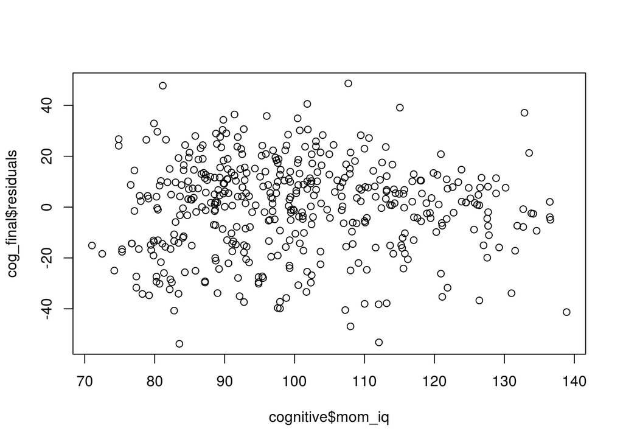

```r
cog_final = lm(kid_score ~ mom_hs + mom_iq + mom_work, data = cognitive);

plot(cog_final$residuals ~ cognitive$mom_iq);
```

## 2. Nearly normal residuals with mean 0

- Some residuals will be positive and some negative.
- On a residuals plot we look for random scatter of residuals around 0.
- This translates to a nearly normal distribution of residuals centered at 0.
- Check using historgram or normal probability plot.

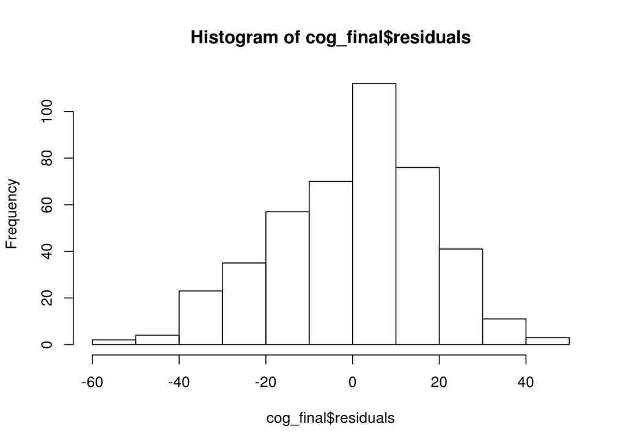

```r
hist(cog_final$residuals);
```

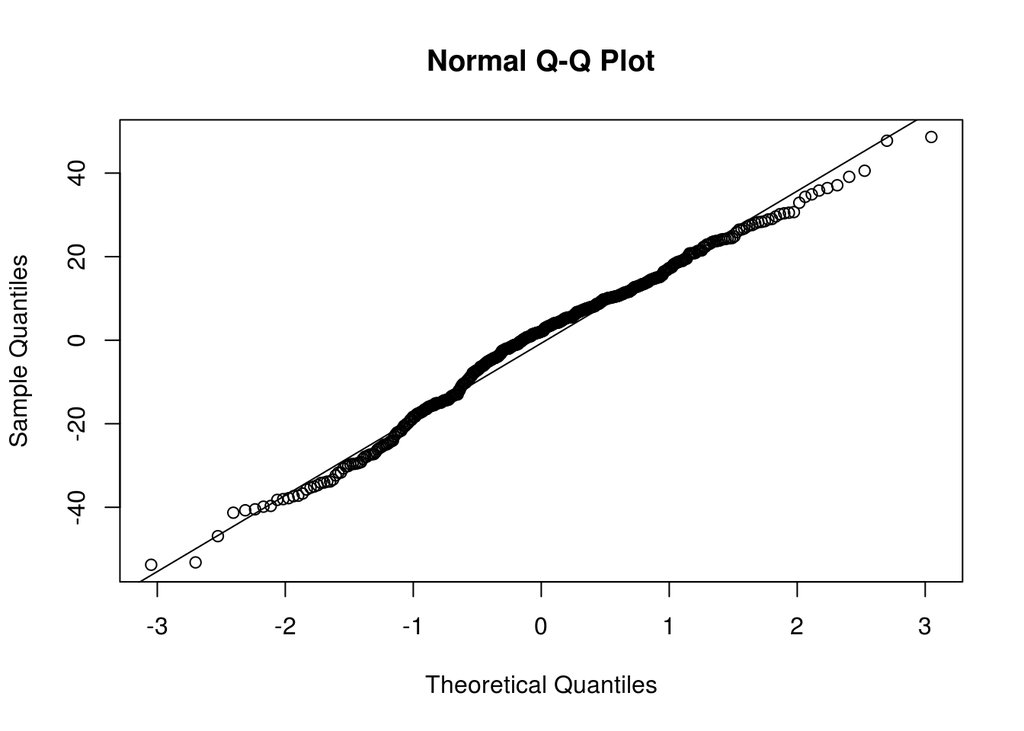

```r
qqnorm(cog_final$residuals);
qqline(cog_final$residuals);
```

## 3. Constant variability of residuals.

- Residuals should be equally variable for low and high values of the predicted response variable.
- Check using residuals plots of residuals vs. predicted ( e vs ${\hat{y}}$)
  - Residuals vs. predicted instead of residuals vs. x because it allows for considering the entire model (with all explanatory variables) at once.
  - Residuals randomly scatter in a band with a constant width around 0 ( no fan shape).
  - Also worthwhile to view absolute value of residuals vs. predicted to identify unusual observations easily.

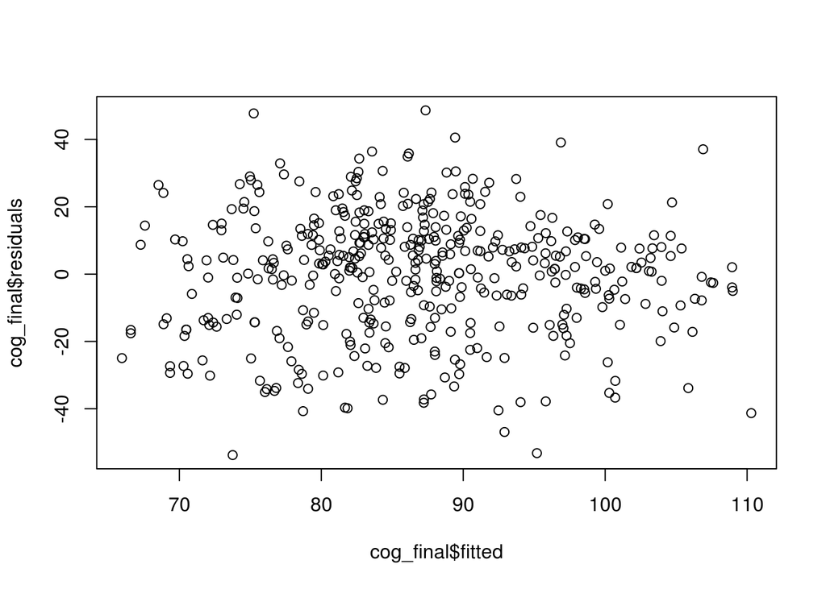

```r
plot(cog_final$residuals ~ cog_final$fitted);
```

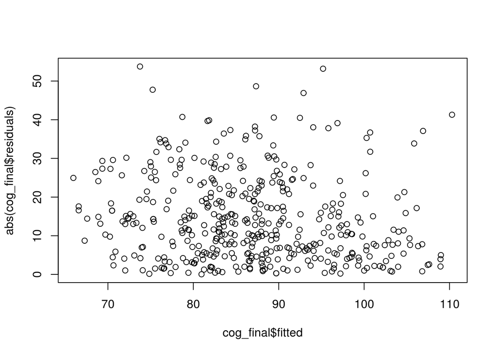

```r
plot(abs(cog_final$residuals) ~ cog_final$fitted);
```

## 4. Independent residuals.

- Independent residuals -> independent observations.
- If time series structure is suspected check using residuals vs. order of data collection.
- If not think about how the data are sampled.

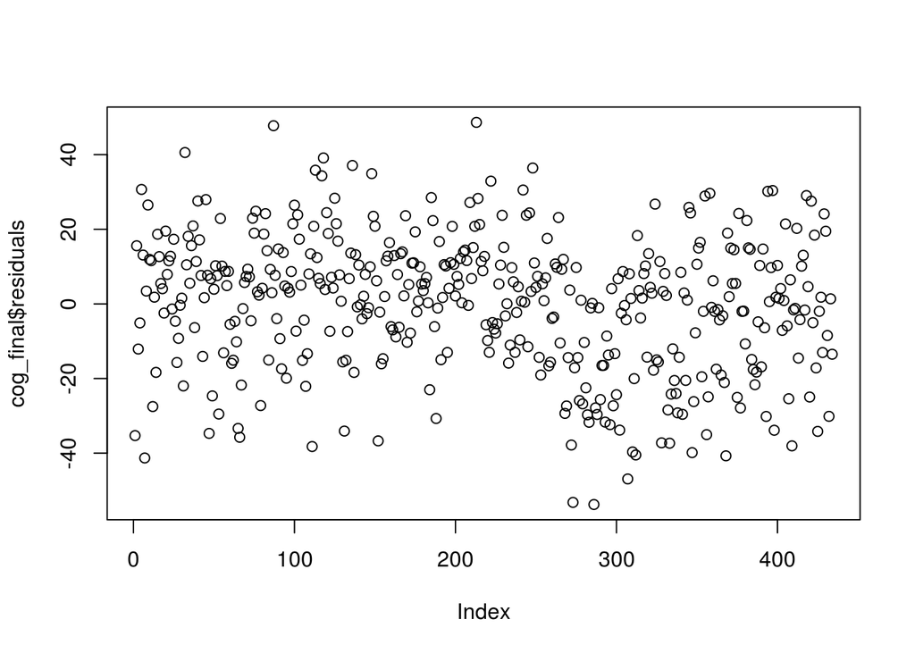

```r
plot(cog_final$residuals);
```